# Assignment 3

```r
library(tidyverse)
library(readxl)
library(ggspatial)
library(ggOceanMaps)
library(here)
```

Open data in Excel to inspect it.

- First line gives units (`skip`)
- First column has notes after the data, could remove with `nmax` or ignore and remove with `drop_na` later
- missing values coded as NA (also n.d. for not detected (almost zero) but not in columns of interest.
- degree signs on some coordinates

```r
orca_contam <- read_excel(
  path = here("data/etc5064-sup-0002-supplementary_dataset.xlsx"),
  sheet = "Sheet1",
  skip = 1,
  na = c("", "NA") # treat blank cells and "NA" as NA
) |>
  janitor::clean_names() |>
  drop_na(lat) # drops rows containing notes
```

If you don’t fix the `na` argument during import, you need to make hbb column numeric later.

Need to remove degree signs and convert to lat/long to numeric. Can do this one at a time, but here I use `across()` to process both columns at once.

```r
orca_contam <- orca_contam |>
  mutate(
    across(c(lat, long), .fns = str_remove, pattern = "°"),
    across(c(lat, long), .fns = as.numeric)) |>
  filter(tissue == "Blubber")
```

Some computers didn’t show the ° symbol, but instead a unicode symbol. This is probably because R guessed the encoding wrong. It should be possible to fix the encoding (see https://stat545.com/character-encoding.html), but can also `str_remove(lat, "\u00b0")` to remove the code, or `str_sub()` to truncate the number of characters at 8 or 9, removing the problematic character.

Making a map. Can use either `rnaturalearth` or `ggOceanMaps` for the basemap. `ggmap` or other map tiles possible but makes colour picking harder and the map a bit cluttered.

Here, I have calculated the limits from the data (because I am using the rotate argument, `basemap()` won’t calculate them nicely by itself). I’m using rotate so that the central meridian is vertical, otherwise Norway leans a lot. I’ve changed the colour of the land and made the points larger than default so they are more visible.

```
Assuming `crs = 4326` in stat_spatial_identity()
```

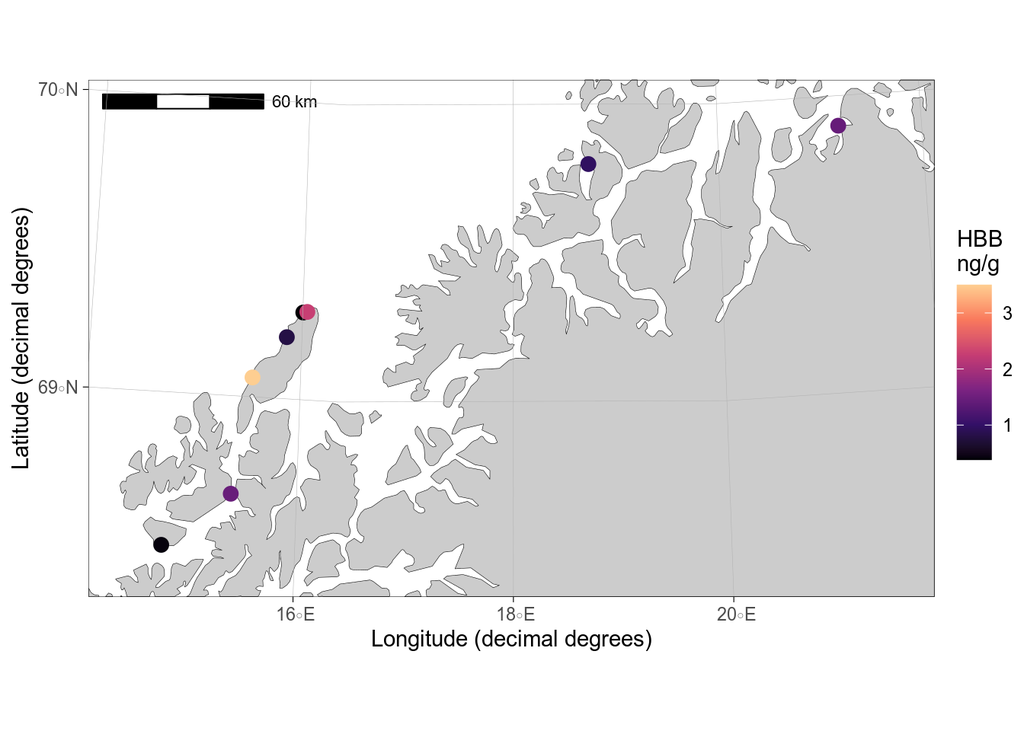

```r
# function to give the map some space around the data
expand_range <- function(x, expand.factor = 0.1){
  r <- range(x)
  dr <- diff(r) * expand.factor
  r + c(-dr, dr)
}

orca_map <- basemap(
  limits = c(expand_range(orca_contam$long), expand_range(orca_contam$lat)),
  land.col = "grey80",
  rotate = TRUE
  ) +
  geom_spatial_point(mapping = aes(x = long, y = lat, colour = hbb), data = orca_contam, size = 3) +
  labs(colour = "HBB\nng/g") +
  annotation_scale(location = "tl") +
  scale_colour_viridis_c(option = "magma", end = 0.9)
orca_map
```

Lets add an inset map. Here I am being careful to make the red rectangle exactly match the main map. This would be much easier with an equirectangular projection (as maps with rnaturalearth have by default).

```r
# want bounding box of map
# available from attributes()
attributes(orca_map)
```

[output not shown]

[output cut: 10 more lines]

[output not shown]

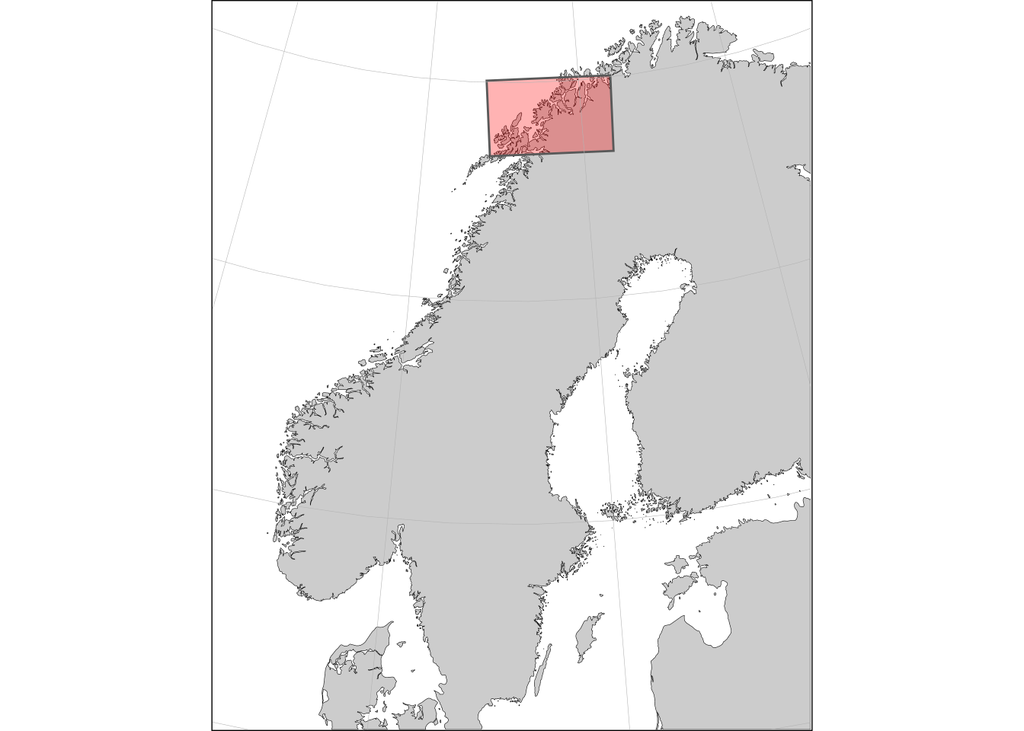

```r
#can get specific elements with attr()
orca_bb <- attr(orca_map, "limits")

inset_map <- basemap(limits = c(4, 27, 55.5, 71.5), rotate = TRUE, land.col = "grey80") +
    geom_spatial_rect(
      mapping = aes(xmin = orca_bb[1], xmax = orca_bb[2], ymin = orca_bb[3], ymax = orca_bb[4]),
      data = NULL,
      fill = "red",
      alpha = 0.3,
      crs = attr(orca_map, "proj")) +
  theme(
    axis.title = element_blank(),
    axis.text = element_blank(),
    axis.ticks.x = element_blank(),
    axis.ticks.y = element_blank(),
    plot.background = element_rect(fill = "white"),
    panel.border = element_blank(),
    plot.margin = margin(1, 1, -2, -2, unit = "pt") # adjusting margins to avoid white space
  )
inset_map
```

```
Assuming `crs = 4326` in stat_spatial_identity()
```

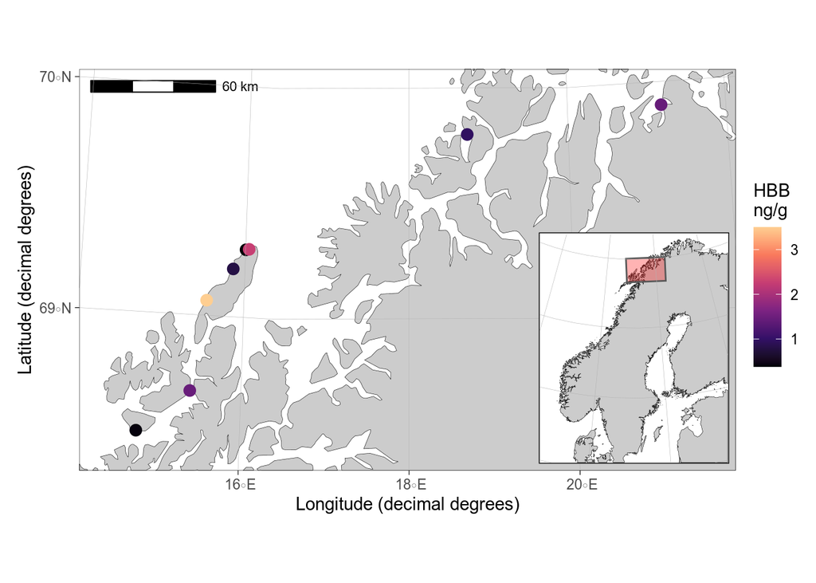

```r
library(patchwork)
orca_map +
  inset_element(inset_map,
                left = 0.7,
                right = 0.99,
                top = 0.6,
                bottom = 0.01)
```

Map is OK but two points are overlapping and difficult to see. Setting alpha doesn’t help much as it just looks like another colour

can use `geom_spatial_label_repel()` (equivalent to `ggrepel::geom_label_repel()`

```
Assuming `crs = 4326` in stat_spatial_identity()
Assuming `crs = 4326` in stat_spatial_identity()
```

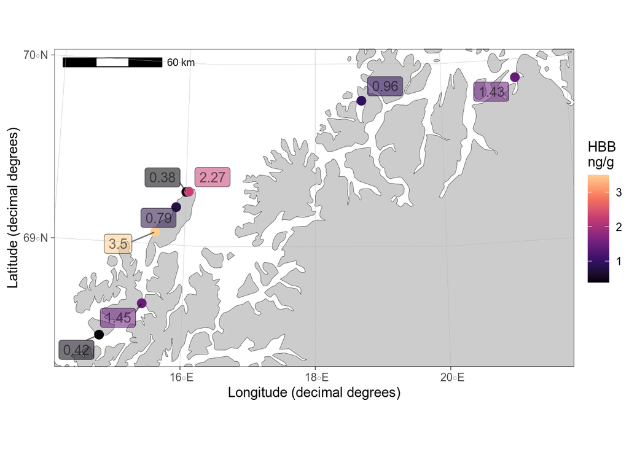

```r
orca_map +
  geom_spatial_label_repel(data = orca_contam, mapping = aes(x = long, y = lat, label = round(hbb, 2), fill = hbb, alpha = 0.4), show.legend = FALSE) +
   scale_fill_viridis_c(option = "magma", end = 0.9)
```

I don’t like that very much. Perhaps labels that only popup when you mouse-over would work better.

```r
library(ggiraph)

bm <- basemap(
  limits = c(expand_range(orca_contam$long), expand_range(orca_contam$lat)),
  land.col = "grey80",
  rotate = TRUE
  )

# there isn't a geom_spatial_point_interactive,
# so we need to transform coordinates to the same as the base map
transformed_orca <- xy_transform(
  x = orca_contam$long,
  y = orca_contam$lat,
  to = attr(bm, "proj")
  ) |>
  bind_cols(orca_contam)

#make map
orca_map_int <- bm +
  geom_point_interactive(
    aes(x = x, y = y,
        tooltip = glue::glue("id = {whale_id}\nHBB = {round(hbb, 3)} ng/g"),
        data_id = whale_id,
        colour = hbb),
    data = transformed_orca,
    size = 3) +
  labs(colour = "HBB\nng/g") +
  annotation_scale(location = "tl") +
  scale_colour_viridis_c(option = "magma", end = 0.9)

# add inset map
orca_map_int <- orca_map_int +
  inset_element(inset_map,
                left = 0.7,
                right = 0.99,
                top = 0.6,
                bottom = 0.01)

# make interactive
girafe(ggobj = orca_map_int,
      options = list(
        opts_sizing(width = 0.8),
        opts_zoom(max = 5)))
```

[interactive chart not shown]

Other interactive graphics packages include `plotly` and `leaflets` (maps only).

Interactive graphics only work in html.

## Other points

Sweden exists! Norway is not an island. If using rnaturalearth can use

```
Assuming `crs = 4326` in stat_spatial_identity()
```

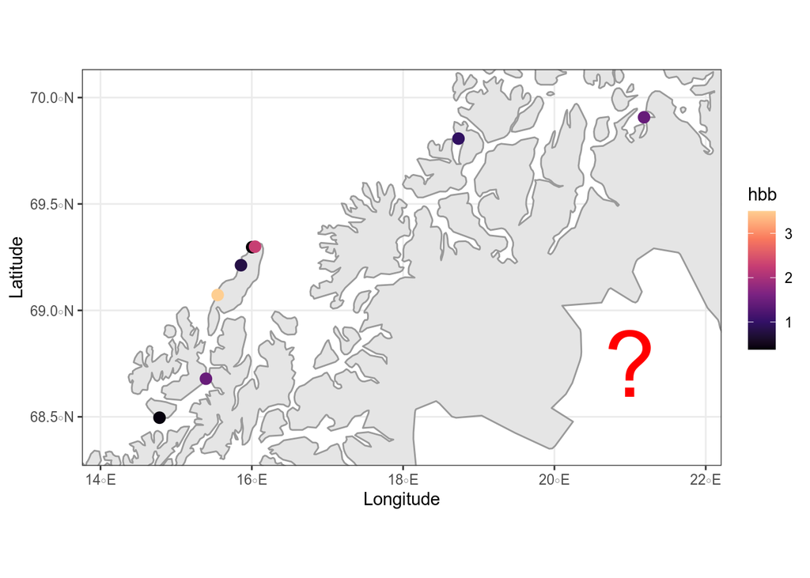

```r
library(rnaturalearth)

base <- ne_countries(scale = 10, country = c("Norway"), returnclass = "sf")

ggplot(base) + # bad
  geom_sf(colour = "grey60") +
  geom_spatial_point(
    data = orca_contam,
    mapping = aes(x = long, y = lat, colour = hbb),
    size = 3) +
  scale_colour_viridis_c(option = "magma", end = 0.9) +
  coord_sf(xlim = expand_range(orca_contam$long),
           ylim = expand_range(orca_contam$lat)) +
  labs(x = "Longitude", y = "Latitude") +
  annotate("text", x = 21, y = 68.75, label = "?", colour = "red", size = 20) +
  theme_bw()
```

```
Assuming `crs = 4326` in stat_spatial_identity()
```

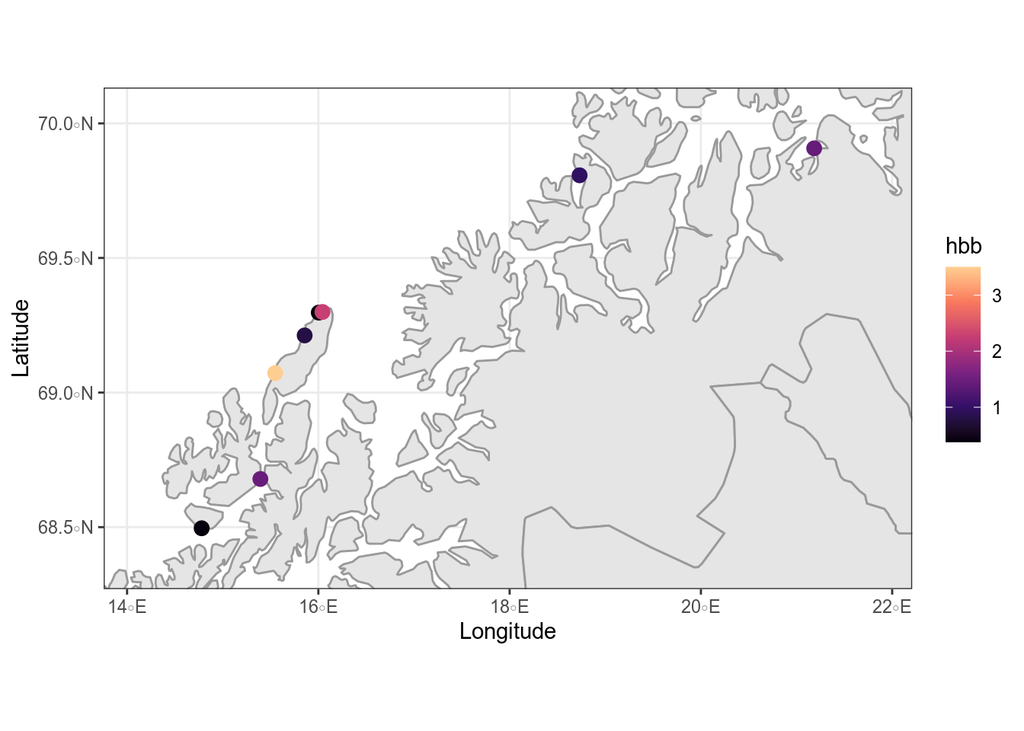

```r
base <- ne_countries(scale = 10, country = c("Norway", "Sweden", "Finland"), returnclass = "sf")

ggplot(base) + # better
  geom_sf(colour = "grey60") +
  geom_spatial_point(
    data = orca_contam,
    mapping = aes(x = long, y = lat, colour = hbb),
    size = 3) +
  scale_colour_viridis_c(option = "magma", end = 0.9) +
  coord_sf(xlim = expand_range(orca_contam$long),
           ylim = expand_range(orca_contam$lat)) +
  labs(x = "Longitude", y = "Latitude") +
  theme_bw()
```

If you use labels on the map, e.g. with `ggrepel`, round any numbers to have a reasonable number of digits. But don’t round the data except when you are going to print it. Your `aes()` can look like this

```r
aes(x = lat, y = long, label = round(hbb, digits = 2))
```

If your legend title is very long it takes up space that should be used for the map. Either move the legend to below the figure `theme(legend.position = "bottom")` or split onto several lines by inserting `\n`

Using fill aesthetic on points with only a colour.

Be careful with size aesthetic. Can work but can lose small points.

Using `select()` with column numbers is almost always a bad idea. Code is difficult to understand and breaks if an extra column is added.

Using `slice()` with numbers rather than `filter()` with a logical condition to pick rows is always a bad idea (`slice()` is fine to pick the first row etc)

`mutate()` is your friend if you want to add or modify a column.

Many scripts used `geom_point()` rather than `geom_spatial_point()`. This worked because they were using `rnaturalearth` and not changing the map projection (so using an equirectangular projection). `geom_spatial_point()` works with projected maps (as `ggOceanMaps` will make). Projecting maps can be useful to avoid distortions, especially at high latitudes.

Be careful of cropping the basemap. If you do crop to make the sf object smaller, leave a buffer zone so the crop does not show up in the figure.